# Temperature Readings : IOT Devices

## Relational dataset from IOT devices to record temperaure readings.

Project and data made available on Kaggle [here](https://www.kaggle.com/atulanandjha/temperature-readings-iot-devices/data)

The goal of this project is to extract insights from temperature data recorded by IoT devices installed inside and outside of an anonymous room. I am tasked with discovering:

- What was the max and min temperature for both the outside and the inside space?
- How is the outside temperature related to the inside temperature? any relation or statistical significance between the two?

I will also explore:

- Measures of central tendency/spread. Do they make sense for inside/outside temp data? What was the variance for inside/outside temp?
- What was the warmest and coolest month (outside)?

I will perform the descriptive stats first, as this will help check for errors and clean the data.

## Exploring the Data:

Data dictionary from Kaggle:

| Column Name | Description |
| --- | --- |
| id | Unique IDs for each reading |
| room_id/id | Room ID for inside/outside device install |
| noted_date | Date and time of reading (dd-mm-yyyy) |
| temp | Temperature reading (deg C) |
| out/in | Whether reading was in/outside of room |

Open the data to explore:

```python
# Import reader function from the csv module
from csv import reader
# Import other modules for creating datetime obj, calling stats funcs, creating visualizations
from datetime import datetime
import numpy as np
from scipy import stats
import matplotlib
import matplotlib.dates as mdates
import matplotlib.pyplot as plt
import plotly.graph_objects as go

# Opening the 'IOT-temp' data set
opened_file = open('IOT-temp.csv')
read_file = reader(opened_file)
iot_temps = list(read_file)
# Separating the header from the data
iot_temps_header = iot_temps[0]
iot_temps = iot_temps[1:]
```

To make it easier to explore the data, we'll create a function to print data rows in a readable way that is easy to reuse.

```python
def explore_data(dataset, start, end, rows_and_columns=False):
    dataset_slice = dataset[start:end]
    for row in dataset_slice:
        # Print and add a new line break after each row
        print(row)
        print('\n')

    # Optionally, view total number of rows/columns if the default
    # for rows_and_columns is changed to True
    if rows_and_columns:
        print('Number of rows:', len(dataset))
        print('Number of columns:', len(dataset[0]))
```

We'll print the header and several data rows to get an idea of what we're working with.

```python
print(iot_temps_header, '\n')
explore_data(iot_temps, 0, 15, True)
```

```
['id', 'room_id/id', 'noted_date', 'temp', 'out/in']

['__export__.temp_log_196134_bd201015', 'Room Admin', '08-12-2018 09:30', '29', 'In']


['__export__.temp_log_196131_7bca51bc', 'Room Admin', '08-12-2018 09:30', '29', 'In']


['__export__.temp_log_196127_522915e3', 'Room Admin', '08-12-2018 09:29', '41', 'Out']


['__export__.temp_log_196128_be0919cf', 'Room Admin', '08-12-2018 09:29', '41', 'Out']


['__export__.temp_log_196126_d30b72fb', 'Room Admin', '08-12-2018 09:29', '31', 'In']


['__export__.temp_log_196125_b0fa0b41', 'Room Admin', '08-12-2018 09:29', '31', 'In']


['__export__.temp_log_196121_01544d45', 'Room Admin', '08-12-2018 09:28', '29', 'In']


['__export__.temp_log_196122_f8b80a9f', 'Room Admin', '08-12-2018 09:28', '29', 'In']


['__export__.temp_log_196111_6b7a0848', 'Room Admin', '08-12-2018 09:26', '29', 'In']


['__export__.temp_log_196112_e134aebd', 'Room Admin', '08-12-2018 09:26', '29', 'In']


['__export__.temp_log_196108_4a983c7e', 'Room Admin', '08-12-2018 09:25', '42', 'Out']


['__export__.temp_log_196108_4a983c7e', 'Room Admin', '08-12-2018 09:25', '42', 'Out']


['__export__.temp_log_196101_d5ec7633', 'Room Admin', '08-12-2018 09:24', '29', 'In']


['__export__.temp_log_196099_3b8ef67b', 'Room Admin', '08-12-2018 09:24', '29', 'In']


['__export__.temp_log_196095_788b2c27', 'Room Admin', '08-12-2018 09:22', '29', 'In']


Number of rows: 97606
Number of columns: 5
```

## Cleaning the data:

Before we consider doing any real analysis, we'll want to check for erroneous and/or duplicate data. We'll first check for any duplicate IDs.

```python
unique_ids = []
duplicate_ids = []

for row in iot_temps:
    value = row[0]
    if value in unique_ids:
        duplicate_ids.append(row)
    else:
        unique_ids.append(value)

print('There are', len(unique_ids), 'unique data IDs.')
print('There are', len(duplicate_ids), 'duplicates.\n')
```

```
There are 97605 unique data IDs.
There are 1 duplicates.
```

Let's view the duplicate to find the ID.

```python
explore_data(duplicate_ids, 0, 1)
```

```
['__export__.temp_log_196108_4a983c7e', 'Room Admin', '08-12-2018 09:25', '42', 'Out']
```

Now we'll look at the readings with identical IDs within the data set.

```python
for row in iot_temps:
    ids = row[0]
    if ids == "__export__.temp_log_196108_4a983c7e":
        print(row, '\n')
```

```
['__export__.temp_log_196108_4a983c7e', 'Room Admin', '08-12-2018 09:25', '42', 'Out']

['__export__.temp_log_196108_4a983c7e', 'Room Admin', '08-12-2018 09:25', '42', 'Out']
```

This is the only potential true duplicate, since every value is identical for all columns. We will remove this along with the other types we discuss below.

There is [a discussion](https://www.kaggle.com/atulanandjha/temperature-readings-iot-devices/discussion/121321) about duplicate data rows occuring due to the seconds data being truncated from the 'noted_date' column. Given the temps are represented as integers and there's nothing useful to extract from the IDs, there's likely to be quite a few duplicates. We'll need to identify these and remove them. We can also already see duplicates in our exploration sample above (for this data set, duplicates will have different IDs but the other values are exact matches)

```python
unique_rows = []
duplicate_rows = []

for row in iot_temps:
    values_to_check = row[2:]
    if values_to_check in unique_rows:
        duplicate_rows.append(row)
    else:
        unique_rows.append(values_to_check)

print('There are', len(unique_rows), 'unique data rows.')
print('There are', len(duplicate_rows), 'duplicates.')
```

```
There are 37268 unique data rows.
There are 60338 duplicates.
```

We will now sort and explore a subset of the duplicates.

```python
def custom_sort_key(item):
    return item[2]
duplicate_rows.sort(key=custom_sort_key)
explore_data(duplicate_rows, 0, 15, True)
```

```
['__export__.temp_log_100245_00f9ae4a', 'Room Admin', '01-11-2018 09:59', '47', 'Out']


['__export__.temp_log_104495_65b410d9', 'Room Admin', '01-11-2018 10:13', '46', 'Out']


['__export__.temp_log_123323_f2f4fd67', 'Room Admin', '01-11-2018 10:26', '46', 'Out']


['__export__.temp_log_92145_b27bb12e', 'Room Admin', '01-11-2018 10:39', '46', 'Out']


['__export__.temp_log_90776_0d49c4ac', 'Room Admin', '01-11-2018 10:39', '46', 'Out']


['__export__.temp_log_101545_7d43fef5', 'Room Admin', '01-11-2018 10:53', '46', 'Out']


['__export__.temp_log_171456_a6e6de9d', 'Room Admin', '01-12-2018 00:00', '37', 'Out']


['__export__.temp_log_171463_f7832fdd', 'Room Admin', '01-12-2018 00:04', '37', 'Out']


['__export__.temp_log_171468_25111bc5', 'Room Admin', '01-12-2018 00:12', '36', 'Out']


['__export__.temp_log_171470_12b4e1e2', 'Room Admin', '01-12-2018 00:14', '36', 'Out']


['__export__.temp_log_171479_f382cfb9', 'Room Admin', '01-12-2018 00:22', '36', 'Out']


['__export__.temp_log_171483_004604bc', 'Room Admin', '01-12-2018 00:26', '36', 'Out']


['__export__.temp_log_171484_9bd9e50d', 'Room Admin', '01-12-2018 00:30', '36', 'Out']


['__export__.temp_log_171490_977e7774', 'Room Admin', '01-12-2018 00:32', '36', 'Out']


['__export__.temp_log_171494_4d9368f9', 'Room Admin', '01-12-2018 00:38', '36', 'Out']


Number of rows: 60338
Number of columns: 5
```

Create an empty list of lists and append only the unique rows.

```python
iot_temps_dedup = []

for row in iot_temps:
    if row not in duplicate_rows:
        iot_temps_dedup.append(row)

explore_data(iot_temps_dedup, 0, 15, True)
```

```
['__export__.temp_log_196134_bd201015', 'Room Admin', '08-12-2018 09:30', '29', 'In']


['__export__.temp_log_196127_522915e3', 'Room Admin', '08-12-2018 09:29', '41', 'Out']


['__export__.temp_log_196126_d30b72fb', 'Room Admin', '08-12-2018 09:29', '31', 'In']


['__export__.temp_log_196121_01544d45', 'Room Admin', '08-12-2018 09:28', '29', 'In']


['__export__.temp_log_196111_6b7a0848', 'Room Admin', '08-12-2018 09:26', '29', 'In']


['__export__.temp_log_196101_d5ec7633', 'Room Admin', '08-12-2018 09:24', '29', 'In']


['__export__.temp_log_196095_788b2c27', 'Room Admin', '08-12-2018 09:22', '29', 'In']


['__export__.temp_log_196094_38501388', 'Room Admin', '08-12-2018 09:21', '41', 'Out']


['__export__.temp_log_196090_b5f7ca9c', 'Room Admin', '08-12-2018 09:20', '29', 'In']


['__export__.temp_log_196085_1e3e9e86', 'Room Admin', '08-12-2018 09:19', '42', 'Out']


['__export__.temp_log_196082_e025abaa', 'Room Admin', '08-12-2018 09:18', '29', 'In']


['__export__.temp_log_196080_911f4eef', 'Room Admin', '08-12-2018 09:17', '41', 'Out']


['__export__.temp_log_196077_d97a0ff1', 'Room Admin', '08-12-2018 09:16', '29', 'In']


['__export__.temp_log_196073_6cce2ad3', 'Room Admin', '08-12-2018 09:14', '29', 'In']


['__export__.temp_log_196065_a29349e0', 'Room Admin', '08-12-2018 09:12', '29', 'In']


Number of rows: 37267
Number of columns: 5
```

It's a good idea to extract our date/time string into a datetime obj and month only (both for use in plotting later). While exploring the data, I noticed that the 'noted_date'column includes two different date/time formats: %d-%m-%Y and %d/%m%Y, but fortunately our deduping process removed the '/' formatted dates already.

```python
for row in iot_temps_dedup:
    date_time = row[2]
    # Extract date object from the 'noted_date' str
    date_obj = datetime.strptime(date_time, "%d-%m-%Y %H:%M")
    # Create and append month date str we'll use later
    month = date_obj.strftime("%b")
    row.append(date_obj)
    row.append(month)

# Explore updated iot_temps_dedup data set
explore_data(iot_temps_dedup, 0, 1, True)
```

```
['__export__.temp_log_196134_bd201015', 'Room Admin', '08-12-2018 09:30', '29', 'In', datetime.datetime(2018, 12, 8, 9, 30), 'Dec']


Number of rows: 37267
Number of columns: 7
```

Now to check for any outliers and get a sense for the data set, we will perform some basic descriptive statistics. Before doing that, let's separate the inside and outside temp data.

```python
inside_temps = []
outside_temps = []

for row in iot_temps_dedup:
    location = row[4]
    if location.lower() == 'in':
        inside_temps.append(row)
    else:
        outside_temps.append(row)

explore_data(inside_temps, 0, 5, True)
print('\n')
explore_data(outside_temps, 0, 5, True)
```

```
['__export__.temp_log_196134_bd201015', 'Room Admin', '08-12-2018 09:30', '29', 'In', datetime.datetime(2018, 12, 8, 9, 30), 'Dec']


['__export__.temp_log_196126_d30b72fb', 'Room Admin', '08-12-2018 09:29', '31', 'In', datetime.datetime(2018, 12, 8, 9, 29), 'Dec']


['__export__.temp_log_196121_01544d45', 'Room Admin', '08-12-2018 09:28', '29', 'In', datetime.datetime(2018, 12, 8, 9, 28), 'Dec']


['__export__.temp_log_196111_6b7a0848', 'Room Admin', '08-12-2018 09:26', '29', 'In', datetime.datetime(2018, 12, 8, 9, 26), 'Dec']


['__export__.temp_log_196101_d5ec7633', 'Room Admin', '08-12-2018 09:24', '29', 'In', datetime.datetime(2018, 12, 8, 9, 24), 'Dec']


Number of rows: 9942
Number of columns: 7


['__export__.temp_log_196127_522915e3', 'Room Admin', '08-12-2018 09:29', '41', 'Out', datetime.datetime(2018, 12, 8, 9, 29), 'Dec']


['__export__.temp_log_196094_38501388', 'Room Admin', '08-12-2018 09:21', '41', 'Out', datetime.datetime(2018, 12, 8, 9, 21), 'Dec']


['__export__.temp_log_196085_1e3e9e86', 'Room Admin', '08-12-2018 09:19', '42', 'Out', datetime.datetime(2018, 12, 8, 9, 19), 'Dec']


['__export__.temp_log_196080_911f4eef', 'Room Admin', '08-12-2018 09:17', '41', 'Out', datetime.datetime(2018, 12, 8, 9, 17), 'Dec']


['__export__.temp_log_196056_de074bc3', 'Room Admin', '08-12-2018 09:09', '42', 'Out', datetime.datetime(2018, 12, 8, 9, 9), 'Dec']


Number of rows: 27325
Number of columns: 7
```

```python
inside = []
outside = []

# Pull temp data and set type to int
for row in inside_temps:
    temps = int(row[3])
    inside.append(temps)

for row in outside_temps:
    temps = int(row[3])
    outside.append(temps)

# Sum for each temp type
sum_inside = sum(inside)
sum_outside = sum(outside)

# Count for each temp type
count_inside = len(inside)
count_outside = len(outside)

# Mean
avg_inside = round( sum_inside / count_inside, 1 )
avg_outside = round( sum_outside / count_outside, 1 )

# Median: Call NumPy func for median
median_inside = np.median(inside)
median_outside = np.median(outside)

#Mode: Call SciPy func for mode
mode_inside = stats.mode(inside)
mode_outside = stats.mode(outside)
#Store tuple output in a more useful way:
mode_inside_val = int(mode_inside[0])
mode_outside_val = int(mode_outside[0])
mode_inside_freq = int(mode_inside[1])
mode_outside_freq = int(mode_outside[1])

# Min
min_inside = min(inside)
min_outside = min(outside)

# Max
max_inside = max(inside)
max_outside = max(outside)

# Range
range_inside = max_inside - min_inside
range_outside = max_outside - min_outside

# Standard Deviation: Call func from NumPy
std_inside = round( np.std(inside), 1 )
std_outside = round( np.std(outside), 1 )

# Variance: Call func from NumPy
var_inside = round( np.var(inside), 1 )
var_outside = round( np.var(outside), 1 )
```

# Analysis & Results

**What was the max and min temperature for both the outside and the inside space?**

**Measures of central tendency/spread. Do they make sense for inside/outside temp data? What was the variance for inside/outside temp?**

Given that the mean/median/mode are well correlated for both the inside and outside temperature readings, our data set is quite normally and fairly uniformly distributed (especially for the inside temp readings). The outside readings have a greater variance, **36.2 v. 5.1**, which makes sense in an uncontrolled environment and given there is a broader range in recorded temps. For further exploration it would be interesting to compare variance annually or seasonally; unfortunately, this data set only covers about half of 2018. It is also noteworthy that this dataset (even before the dedup process) contains significantly more outside readings than inside, roughly **2.5:1**. It would be more interesting to compare the two if this difference was much less pronounced.

The tables and figures below represent the calculated descriptive statistics and visualizations of the temperature data distribution and inside/outside reading comparison.

```python
# Set labels, assign data to display
fig = go.Figure(data=[go.Table(header=dict(values=['', 'Min', 'Max', 'Mean', 'Median',
                                                   'Mode', 'Mode Freq', 'Range', 'St Dev', 'Var'
                                                  ]),
                 cells=dict(values=[ ['Inside','Outside'], [min_inside, min_outside], [max_inside, max_outside],
                                    [avg_inside, avg_outside], [median_inside, median_outside],
                                    [mode_inside_val, mode_outside_val], [mode_inside_freq, mode_outside_freq],
                                    [range_inside, range_outside], [std_inside, std_outside], [var_inside, var_outside]
                                   ]))
                     ])
# Assign title and format
fig.update_layout(title={
        'text': "Descriptive Statistics",
        'y':0.9,
        'x':0.5,
        'xanchor': 'center',
        'yanchor': 'top'
})
fig.show()
```

[interactive chart not shown]

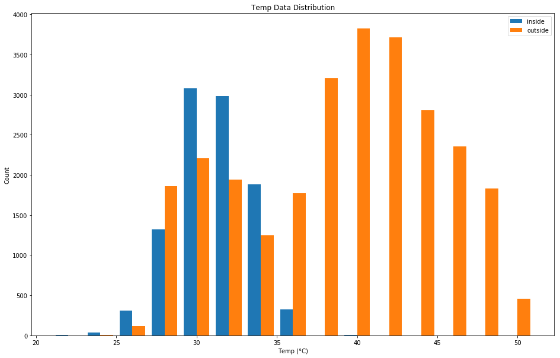

```python
# Setting all matplotlib plots to a larger default size
plt.rcParams["figure.figsize"] = (15.8,10)

# Set labels, bins, and assign data to display
hist_labels = ['inside', 'outside']
hist_x = inside
hist_y = outside
hist_bins = 15
# Plot and format graph
plt.hist([hist_x, hist_y], hist_bins, label=hist_labels)
plt.legend(loc = 'upper right')
plt.xlabel('Temp (°C)')
plt.ylabel('Count')
plt.title('Temp Data Distribution')

plt.show()
```

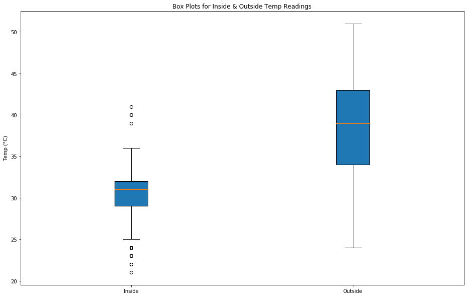

```python
# Set labels, assign data to display
box_labels = ['Inside', 'Outside']
box_data = [inside, outside]
# Plot and format graph
plt.boxplot(box_data, patch_artist=True,labels=box_labels)
plt.ylabel('Temp (°C)')
plt.title('Box Plots for Inside & Outside Temp Readings')

plt.show()
```

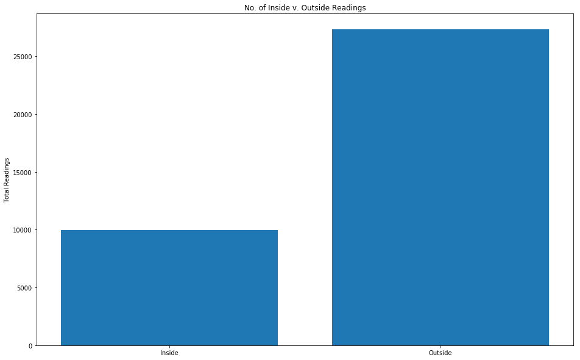

```python
# Set labels, assign data to display
bar_labels = ['Inside', 'Outside']
bar_counts = [count_inside, count_outside]
bar_pos = np.arange(len(bar_labels))
# Plot and format graph
plt.bar(bar_pos, bar_counts, align='center')
plt.xticks(bar_pos, bar_labels)
plt.ylabel('Total Readings')
plt.title('No. of Inside v. Outside Readings')

plt.show()
```

**How is the outside temperature related to the inside temperature? any relation or statistical significance between the two?**

As we think about our statistical data, we will also create a scatter plot for the inside and outside temps that span the entire data set.

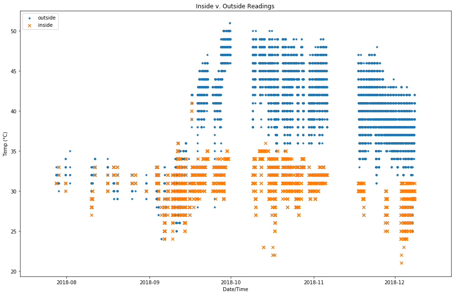

```python
# Assign data to display

# We already have our Y values extracted from the stats we did.  We just
# need to extract the date obj column we created earlier.
inside_x = []
outside_x = []

for row in inside_temps:
    datetime = row[5]
    inside_x.append(datetime)

for row in outside_temps:
    datetime = row[5]
    outside_x.append(datetime)


# Plot and format graph
plt.scatter(outside_x,outside, marker='.', label='outside')
plt.scatter(inside_x,inside, marker='x', label='inside')
plt.legend(loc = 'upper left')
plt.xlabel('Date/Time')
plt.ylabel('Temp (°C)')
plt.title('Inside v. Outside Readings')

plt.show()
```

Referring to the stats and histogram from earlier as well as this visualization, we see that:

- The outside temperature is much more variable overall than inside, which is expected.
- It is significantly warmer on average outside than inside.
- As the outside temperature increases, the inside temperature does not significantly respond.
- There isn't a significant relationship between the outside and inside temperature.

**What was the warmest and coolest month (outside)?**

First, we'll need to find out which months we have in our data set.

```python
outside_months = []

for row in outside_temps:
    month = row[6]
    if month not in outside_months:
        outside_months.append(month)

print(outside_months)
```

```
['Dec', 'Nov', 'Oct', 'Sep', 'Aug', 'Jul']
```

Now, we can find the month with the highest/lowest average temps and create a couple visualizations to help us determine the correct months.

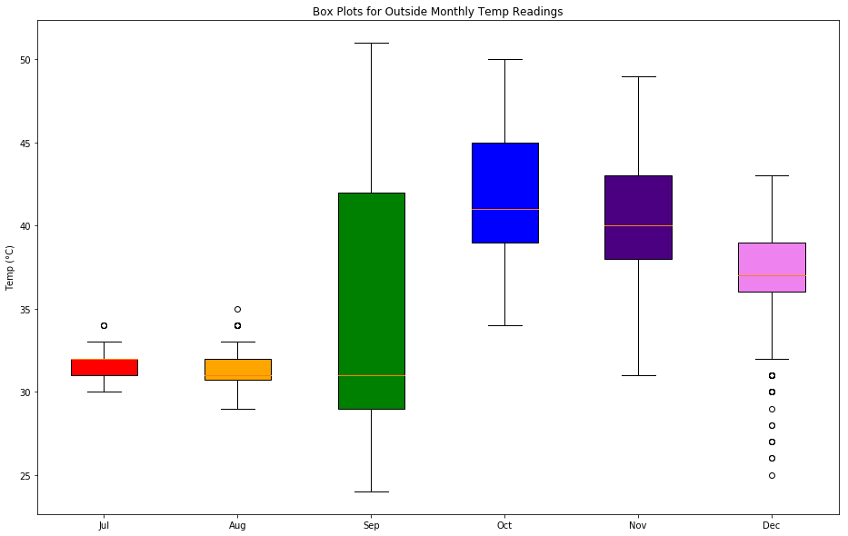

[interactive chart not shown]

```python
temp_jul = []
temp_aug = []
temp_sep = []
temp_oct = []
temp_nov = []
temp_dec = []

#Separate and store temps by month
for row in outside_temps:
    month = row[6]
    temp = int(row[3])

    if month.lower() == 'jul':
        temp_jul.append(temp)
    elif month.lower() == 'aug':
        temp_aug.append(temp)
    elif month.lower() == 'sep':
        temp_sep.append(temp)
    elif month.lower() == 'oct':
        temp_oct.append(temp)
    elif month.lower() == 'nov':
        temp_nov.append(temp)
    elif month.lower() == 'dec':
        temp_dec.append(temp)

# Calc monthly averages
avg_jul = round ( sum(temp_jul) / len(temp_jul), 1 )
avg_aug = round ( sum(temp_aug) / len(temp_aug), 1 )
avg_sep = round ( sum(temp_sep) / len(temp_sep), 1 )
avg_oct = round ( sum(temp_oct) / len(temp_oct), 1 )
avg_nov = round ( sum(temp_nov) / len(temp_nov), 1 )
avg_dec = round ( sum(temp_dec) / len(temp_dec), 1 )

# Plot box plots for each month

# Set labels, assign data to display
box_labels = ['Jul', 'Aug', 'Sep', 'Oct', 'Nov', 'Dec']
box_data = [temp_jul, temp_aug, temp_sep, temp_oct, temp_nov, temp_dec]
# Plot and format graph
box = plt.boxplot(box_data, patch_artist=True,labels=box_labels)
plt.ylabel('Temp (°C)')
plt.title('Box Plots for Outside Monthly Temp Readings')

colors = ['red', 'orange', 'green', 'blue', 'indigo', 'violet']

for patch, color in zip(box['boxes'], colors):
    patch.set_facecolor(color)

plt.show()


# Make a table to display the monthly averages:

# Set labels, assign data to display
fig = go.Figure(data=[go.Table(header=dict(values=['Month', 'Avg Temp (°C)']),
                 cells=dict(values=[ ['Jul', 'Aug', 'Sep', 'Oct', 'Nov', 'Dec'],
                                    [avg_jul, avg_aug, avg_sep, avg_oct, avg_nov, avg_dec]]))
                     ])
# Assign title and format
fig.update_layout(title={
        'text': "Avg Monthly Outside Temp",
        'y':0.9,
        'x':0.5,
        'xanchor': 'center',
        'yanchor': 'top'
})
fig.show()
```

I was also curious how many readings we have by month:

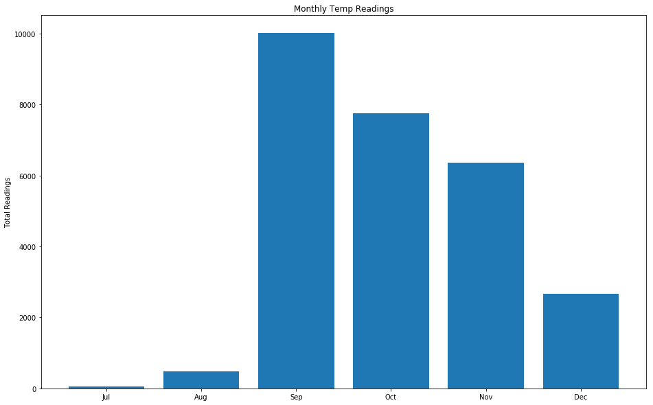

```python
# Set labels, assign data to display
bar2_labels = ['Jul', 'Aug', 'Sep', 'Oct', 'Nov', 'Dec']
bar2_counts = [len(temp_jul), len(temp_aug), len(temp_sep), len(temp_oct), len(temp_nov), len(temp_dec)]
bar2_pos = np.arange(len(bar2_labels))
# Plot and format graph
plt.bar(bar2_pos, bar2_counts, align='center')
plt.xticks(bar2_pos, bar2_labels)
plt.ylabel('Total Readings')
plt.title('Monthly Temp Readings')

plt.show()
```

It appears that **October has the highest average temp** and **August has the average lowest temp**. Also, September appears to have the greatest overall temperature variance. We also see how unevenly distributed the temperature readings are. It would be ideal to repeat the temp data collection with a much more even distribution.

## Concluding Remarks

It was very interesting to analyze the temperature readings for the inside and outside IoT devices. In a more ideal situation, the number of inside vs. outside as well as month-month readings would be less skewed; I'd be intrigued to see if this has an impact on the analysis. I also do not believe analyzing Celsius temperature readings collected as whole integers is a good idea. This introduces error when checking the distribution of the data set that we cannot take into account - I imagine the distribution would be slightly less uniform and have less central tendency (the mode for the inside and outside device would also be more meaningful).